# predicting the quality of exercise

kalai

3/26/2020

## Introduction

Using devices such as Jawbone Up, Nike FuelBand, and Fitbit it is now possible to collect a large amount of data about personal activity relatively inexpensively. These type of devices are part of the quantified self movement – a group of enthusiasts who take measurements about themselves regularly to improve their health, to find patterns in their behavior, or because they are tech geeks. One thing that people regularly do is quantify how much of a particular activity they do, but they rarely quantify how well they do it. In this project, the goal will be to use data from accelerometers on the belt, forearm, arm, and dumbell of 6 participants. They were asked to perform barbell lifts correctly and incorrectly in 5 different ways.

## Objective

The objective is to correclty predict whether the participants have performed the exercise correctly or not based on the parameters provided in the dataset.

More information on the experiment is available here: http://groupware.les.inf.puc-rio.br/har The training data for this project are available at:

https://d396qusza40orc.cloudfront.net/predmachlearn/pml-training.csv

The test data are available here:

https://d396qusza40orc.cloudfront.net/predmachlearn/pml-testing.csv

The data for this project come from this source: http://groupware.les.inf.puc-rio.br/har.

##Getting and Cleaning Data

```r
trainURL <- "http://d396qusza40orc.cloudfront.net/predmachlearn/pml-training.csv"
testURL <- "http://d396qusza40orc.cloudfront.net/predmachlearn/pml-testing.csv"

training <- read.csv(url(trainURL))
testing <- read.csv(url(testURL))
```

Let’s explore the dataset

```r
dim(training)
```

```
## [1] 19622   160
```

```r
dim(testing)
```

```
## [1]  20 160
```

There are 19622 observations in training set with 160 parameters for each observation For the test test there are 20 observations with 160 parameters

Let’s look at the data

```r
head(training)
```

```
##   X user_name raw_timestamp_part_1 raw_timestamp_part_2   cvtd_timestamp
## 1 1  carlitos           1323084231               788290 05/12/2011 11:23
## 2 2  carlitos           1323084231               808298 05/12/2011 11:23
## 3 3  carlitos           1323084231               820366 05/12/2011 11:23
## 4 4  carlitos           1323084232               120339 05/12/2011 11:23
## 5 5  carlitos           1323084232               196328 05/12/2011 11:23
## 6 6  carlitos           1323084232               304277 05/12/2011 11:23
##   new_window num_window roll_belt pitch_belt yaw_belt total_accel_belt
## 1         no         11      1.41       8.07    -94.4                3
## 2         no         11      1.41       8.07    -94.4                3
## 3         no         11      1.42       8.07    -94.4                3
## 4         no         12      1.48       8.05    -94.4                3
## 5         no         12      1.48       8.07    -94.4                3
## 6         no         12      1.45       8.06    -94.4                3
##   kurtosis_roll_belt kurtosis_picth_belt kurtosis_yaw_belt skewness_roll_belt
```

[output cut: 251 more lines]

```r
head(testing)
```

```
##   X user_name raw_timestamp_part_1 raw_timestamp_part_2   cvtd_timestamp
## 1 1     pedro           1323095002               868349 05/12/2011 14:23
## 2 2    jeremy           1322673067               778725 30/11/2011 17:11
## 3 3    jeremy           1322673075               342967 30/11/2011 17:11
## 4 4    adelmo           1322832789               560311 02/12/2011 13:33
## 5 5    eurico           1322489635               814776 28/11/2011 14:13
## 6 6    jeremy           1322673149               510661 30/11/2011 17:12
##   new_window num_window roll_belt pitch_belt yaw_belt total_accel_belt
## 1         no         74    123.00      27.00    -4.75               20
## 2         no        431      1.02       4.87   -88.90                4
## 3         no        439      0.87       1.82   -88.50                5
## 4         no        194    125.00     -41.60   162.00               17
## 5         no        235      1.35       3.33   -88.60                3
## 6         no        504     -5.92       1.59   -87.70                4
##   kurtosis_roll_belt kurtosis_picth_belt kurtosis_yaw_belt skewness_roll_belt
```

[output cut: 251 more lines]

The classe is the outcome to predict in the test data

First, remove the variables with NaN values and values which have lesser significance.

```r
library(caret)
clean <- nearZeroVar(training, saveMetrics = TRUE)
head(clean)
```

```
##                      freqRatio percentUnique zeroVar   nzv
## X                     1.000000  100.00000000   FALSE FALSE
## user_name             1.100679    0.03057792   FALSE FALSE
## raw_timestamp_part_1  1.000000    4.26562022   FALSE FALSE
## raw_timestamp_part_2  1.000000   85.53154622   FALSE FALSE
## cvtd_timestamp        1.000668    0.10192641   FALSE FALSE
## new_window           47.330049    0.01019264   FALSE  TRUE
```

```r
train <- training[, !clean$nzv]
test <- testing[, !clean$nzv]
dim(train)
```

```
## [1] 19622   100
```

```r
dim(test)
```

```
## [1]  20 100
```

```r
head(train)
```

```
##   X user_name raw_timestamp_part_1 raw_timestamp_part_2   cvtd_timestamp
## 1 1  carlitos           1323084231               788290 05/12/2011 11:23
## 2 2  carlitos           1323084231               808298 05/12/2011 11:23
## 3 3  carlitos           1323084231               820366 05/12/2011 11:23
## 4 4  carlitos           1323084232               120339 05/12/2011 11:23
## 5 5  carlitos           1323084232               196328 05/12/2011 11:23
## 6 6  carlitos           1323084232               304277 05/12/2011 11:23
##   num_window roll_belt pitch_belt yaw_belt total_accel_belt max_roll_belt
## 1         11      1.41       8.07    -94.4                3            NA
## 2         11      1.41       8.07    -94.4                3            NA
## 3         11      1.42       8.07    -94.4                3            NA
## 4         12      1.48       8.05    -94.4                3            NA
## 5         12      1.48       8.07    -94.4                3            NA
## 6         12      1.45       8.06    -94.4                3            NA
##   max_picth_belt min_roll_belt min_pitch_belt amplitude_roll_belt
```

[output cut: 139 more lines]

Now there are 100 parameters for the observations in training and test set. Further removing the parameters that are not needed for the prediction

```r
rem <- grepl("^X|timestamp|user_name", names(train))
train <- train[, !rem]
test <- test[, !rem]
dim(train)
```

```
## [1] 19622    95
```

```r
dim(test)
```

```
## [1] 20 95
```

```r
head(train)
```

```
##   num_window roll_belt pitch_belt yaw_belt total_accel_belt max_roll_belt
## 1         11      1.41       8.07    -94.4                3            NA
## 2         11      1.41       8.07    -94.4                3            NA
## 3         11      1.42       8.07    -94.4                3            NA
## 4         12      1.48       8.05    -94.4                3            NA
## 5         12      1.48       8.07    -94.4                3            NA
## 6         12      1.45       8.06    -94.4                3            NA
##   max_picth_belt min_roll_belt min_pitch_belt amplitude_roll_belt
## 1             NA            NA             NA                  NA
## 2             NA            NA             NA                  NA
## 3             NA            NA             NA                  NA
## 4             NA            NA             NA                  NA
## 5             NA            NA             NA                  NA
## 6             NA            NA             NA                  NA
##   amplitude_pitch_belt var_total_accel_belt avg_roll_belt stddev_roll_belt
```

[output cut: 132 more lines]

Finally let’s remove the na values

```r
n <- (colSums(is.na(train)) == 0)
train <- train[, n]
testing <- test[, n]
dim(train)
```

```
## [1] 19622    54
```

Finally, there are 54 parameters in the training set with which we can proceed for prediction

Importing the required packages

```r
library(rpart)
```

```r
library(rpart.plot)
library(corrplot)
library(randomForest)
```

Setting the seed value for regeneration of same results

```r
set.seed(12345)
```

Visualizing a correlation plot

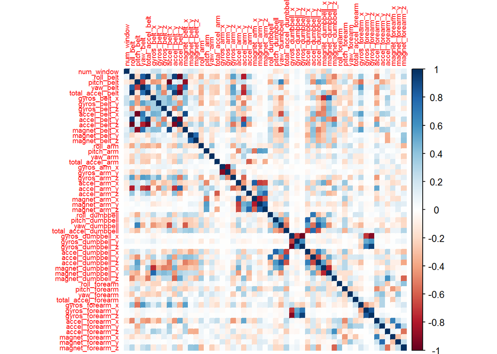

```r
corrplot(cor(train[, -length(names(train))]), method = "color", tl.cex = 0.6)
```

##Datset partitioning

let’s partition the training set into train and test to be useful for cross validation

```r
set.seed(12345)
Train_part <- createDataPartition(train$classe, p = 0.70, list = FALSE)
validate <- train[-Train_part, ]
final_train <- train[Train_part, ]
dim(validate)
```

```
## [1] 5885   54
```

```r
dim(final_train)
```

```
## [1] 13737    54
```

## Using Random Forest

Here, I have used random forest for training and prediction. the cross fold validation value is set to 10.

```r
ranfor <- train(classe ~ ., data = final_train, method = "rf", trControl = trainControl(method = "cv", 10), ntree = 100)
ranfor
```

```
## Random Forest
##
## 13737 samples
##    53 predictor
##     5 classes: 'A', 'B', 'C', 'D', 'E'
##
## No pre-processing
## Resampling: Cross-Validated (10 fold)
## Summary of sample sizes: 12362, 12364, 12364, 12363, 12363, 12364, ...
## Resampling results across tuning parameters:
##
##   mtry  Accuracy   Kappa
##    2    0.9941757  0.9926322
##   27    0.9975978  0.9969614
##   53    0.9956320  0.9944749
##
## Accuracy was used to select the optimal model using the largest value.
## The final value used for the model was mtry = 27.
```

Let’s check the performance of the model on the validation state

```r
predictranfor <- predict(ranfor, validate)
confusionMatrix(validate$classe, predictranfor)
```

```
## Confusion Matrix and Statistics
##
##           Reference
## Prediction    A    B    C    D    E
##          A 1674    0    0    0    0
##          B    1 1136    2    0    0
##          C    0    2 1024    0    0
##          D    0    0    2  962    0
##          E    0    0    0    1 1081
##
## Overall Statistics
##
##                Accuracy : 0.9986
##                  95% CI : (0.9973, 0.9994)
##     No Information Rate : 0.2846
##     P-Value [Acc > NIR] : < 2.2e-16
##
##                   Kappa : 0.9983
##
##  Mcnemar's Test P-Value : NA
##
## Statistics by Class:
##
##                      Class: A Class: B Class: C Class: D Class: E
## Sensitivity            0.9994   0.9982   0.9961   0.9990   1.0000
## Specificity            1.0000   0.9994   0.9996   0.9996   0.9998
## Pos Pred Value         1.0000   0.9974   0.9981   0.9979   0.9991
## Neg Pred Value         0.9998   0.9996   0.9992   0.9998   1.0000
## Prevalence             0.2846   0.1934   0.1747   0.1636   0.1837
## Detection Rate         0.2845   0.1930   0.1740   0.1635   0.1837
## Detection Prevalence   0.2845   0.1935   0.1743   0.1638   0.1839
## Balanced Accuracy      0.9997   0.9988   0.9978   0.9993   0.9999
```

```r
accuracy <- postResample(predictranfor, validate$classe)
outsamplerr <- 1 - as.numeric(confusionMatrix(validate$classe, predictranfor)$overall[1])
accuracy
```

```
##  Accuracy     Kappa
## 0.9986406 0.9982805
```

```r
outsamplerr
```

```
## [1] 0.001359388
```

## Fitting a decision tree

Let’s try a decision tree on the dataset

```r
dtree <- rpart(classe ~ ., data = final_train, method = "class")
predictdtree <- predict(dtree, validate, type = "class")
confusionMatrix(validate$classe, predictdtree)
```

```
## Confusion Matrix and Statistics
##
##           Reference
## Prediction    A    B    C    D    E
##          A 1502   58    4   90   20
##          B  201  660   66  148   64
##          C   59   37  815   54   61
##          D   66   64  129  648   57
##          E   74  114   72  126  696
##
## Overall Statistics
##
##                Accuracy : 0.7342
##                  95% CI : (0.7228, 0.7455)
##     No Information Rate : 0.3232
##     P-Value [Acc > NIR] : < 2.2e-16
##
##                   Kappa : 0.6625
##
##  Mcnemar's Test P-Value : < 2.2e-16
##
## Statistics by Class:
##
##                      Class: A Class: B Class: C Class: D Class: E
## Sensitivity            0.7897   0.7074   0.7505   0.6079   0.7751
## Specificity            0.9568   0.9033   0.9560   0.9344   0.9226
## Pos Pred Value         0.8973   0.5795   0.7943   0.6722   0.6433
## Neg Pred Value         0.9050   0.9425   0.9442   0.9151   0.9579
## Prevalence             0.3232   0.1585   0.1845   0.1811   0.1526
## Detection Rate         0.2552   0.1121   0.1385   0.1101   0.1183
## Detection Prevalence   0.2845   0.1935   0.1743   0.1638   0.1839
## Balanced Accuracy      0.8733   0.8053   0.8532   0.7712   0.8488
```

```r
dtreeaccuracy <- postResample(predictdtree, validate$classe)
dtreeoutsamplerr <- 1 - as.numeric(confusionMatrix(validate$classe, predictdtree)$overall[1])
dtreeaccuracy
```

```
##  Accuracy     Kappa
## 0.7342396 0.6625194
```

```r
dtreeoutsamplerr
```

```
## [1] 0.2657604
```

It can be seen that random forset has higher accuracy when compared to decision tree. Hence let’s use random forest to measure the performance on the test set.

## Predcition on the test set

```r
predict(ranfor, testing[, -length(names(testing))])
```

```
##  [1] B A B A A E D B A A B C B A E E A B B B
## Levels: A B C D E
```

## Conclusion

We can see the predcitions for the test data set